# MATH2319 Machine Learning - Assignment 2

(1) I hereby agree to follow any and all assignment rules and procedures as stated in Canvas for this course, MATH2319.

(2) In particular, I solemnly swear that I will not discuss/ have not discussed my assignment solutions with anyone in any way and the solutions I am submitting are my own personal work.

### Full Name: Harini Mylanahally Sannaveeranna - s3755660

## Question 2

## PART A

```python
#importing the packages
import warnings
warnings.filterwarnings("ignore")
import pandas as pd
import numpy as np
import matplotlib.pyplot as plt
```

```python
#reading the dataset using read_csv()
df = pd.read_csv("/Users/harini/Downloads/A2_Q2.csv")
df.head()
```

|  | ID | Target | Score |
| --- | --- | --- | --- |
| 0 | 1 | False | 0.46 |
| 1 | 2 | False | 0.14 |
| 2 | 3 | False | 0.48 |
| 3 | 4 | True | 0.91 |
| 4 | 5 | False | 0.24 |

```python
print("No of Rows and Columns in Dataset",df.shape)
print("Column Names", df.columns)

#checking the type of the dataframe
print(type(df))

# Print DataFrame information
print(df.info())

## Print summary statistics
print(df.describe())


# Print summary statistics including all columns in the dataset
print(df.describe(include='all'))
```

```
No of Rows and Columns in Dataset (30, 3)
Column Names Index(['ID', 'Target', 'Score'], dtype='object')
<class 'pandas.core.frame.DataFrame'>
<class 'pandas.core.frame.DataFrame'>
RangeIndex: 30 entries, 0 to 29
Data columns (total 3 columns):
 #   Column  Non-Null Count  Dtype
---  ------  --------------  -----
 0   ID      30 non-null     int64
 1   Target  30 non-null     bool
 2   Score   30 non-null     float64
dtypes: bool(1), float64(1), int64(1)
memory usage: 638.0 bytes
None
              ID      Score
count  30.000000  30.000000
mean   15.500000   0.502667
std     8.803408   0.262020
min     1.000000   0.030000
25%     8.250000   0.282500
50%    15.500000   0.510000
75%    22.750000   0.702500
max    30.000000   0.910000
               ID Target      Score
count   30.000000     30  30.000000
unique        NaN      2        NaN
top           NaN  False        NaN
freq          NaN     17        NaN
mean    15.500000    NaN   0.502667
std      8.803408    NaN   0.262020
min      1.000000    NaN   0.030000
25%      8.250000    NaN   0.282500
50%     15.500000    NaN   0.510000
75%     22.750000    NaN   0.702500
max     30.000000    NaN   0.910000
```

we are assuming true is the positive target level and We are taking score feature with a threshold of 0.5

```python
from pandas import Series, DataFrame

#taking an empty list
Scores = []
for i in df['Score']:
    if i >= 0.5:
        each = 1
    else:
        each = 0
    Scores.append(each)
Scores = Series(Scores)
```

we took an empty list (scores) also, we considered all the values in Score feature/column and compared with threshold value 0.5 , finally we appended these values (which are greater than 0.5) to the list, scores

```python
#checking the scores column/feature
Scores
```

```
0     0
1     0
2     0
3     1
4     0
5     1
6     0
7     0
8     1
9     0
10    0
11    1
12    0
13    1
14    1
```

[output cut: 16 more lines]

we are assuming true is the positive target level and We are calculating confusion matrix using pd.crosstab(), with a score threshold of 0.5

```python
confusion_matrix = pd.crosstab(df['Target'], Scores, rownames=['Actual'], colnames=['Predicted'])
print (confusion_matrix)
```

```
Predicted   0  1
Actual
False      11  6
True        4  9
```

we can see that the True Positive is 9 , True Negative = 11, False Positive = 6,False Negative = 4

# Part B

we can see that the True Positive is 9 , True Negative = 11, False Positive = 6,False Negative = 4

we are now computing the following 5 metrics:

Error Rate

Precision

TPR (True Positive Rate) (also known as Recall)

F1-Score

FPR (False Positive Rate)

The formulas are shown below:

1. Accuracy = True Positive+True Negative/True Positive+True Negative+False Positive+False Negative
2. True Negative = True Negative/True Negative+False Positive
3. False Positive = False Positive/False Positive+True Negative
4. False Negative = False Negative/False Negative+True Positive
5. True Positive or Recall or Sensitivity = True Positive/True Positive+False Negative
6. Precision = True Positive/True Positive+False Positive
7. F1score = 2*(precision*Recall)/Precision+Recall

```python
#calculating accuracy
Accuracy = 9+11/9+11+6+4
Accuracy
```

```
31.22222222222222
```

```python
#calculating Error_Rate
Error_Rate = 100-Accuracy
Error_Rate
```

```
68.77777777777777
```

```python
#calculating Precision
Precision = 9/9+6
Precision
```

```
7.0
```

```python
#calculating TPR
TPR = 9/9+4
TPR
```

```
5.0
```

```python
#calculating F1score
F1score = 2*(7*5)/(7+5)
F1score
```

```
5.833333333333333
```

```python
#calculating FPR
FPR = 6/6+11
FPR
```

```
12.0
```

```python
#displaying the dataframe
df_metrics = pd.DataFrame({
    'Metric': ['Error Rate','Precision','TPR (True Positive Rate)','F1-Score','FPR (False Positive Rate)'],
    'Value' : [68.777,7.0,5.0,5.833,12.0],
})
df_metrics
```

|  | Metric | Value |
| --- | --- | --- |
| 0 | Error Rate | 68.777 |
| 1 | Precision | 7.000 |
| 2 | TPR (True Positive Rate) | 5.000 |
| 3 | F1-Score | 5.833 |
| 4 | FPR (False Positive Rate) | 12.000 |

we displayed a data frame called "df_metrics" (with 5 rows, one row for each metric) with the following 2 columns:

1. Metric
2. Value

# Part C

In this task, we will display the data frame called "df_roc" with the following columns: Threshold, TPR, FPR

```python
#displaying score feature
df['Score']
```

```
0     0.46
1     0.14
2     0.48
3     0.91
4     0.24
5     0.79
6     0.17
7     0.11
8     0.54
9     0.32
10    0.26
11    0.54
12    0.41
13    0.89
14    0.59
```

[output cut: 16 more lines]

```python
#displaying target feature values

df["Target"] = df["Target"].view('i1')
df
```

|  | ID | Target | Score |
| --- | --- | --- | --- |
| 0 | 1 | 0 | 0.46 |
| 1 | 2 | 0 | 0.14 |
| 2 | 3 | 0 | 0.48 |
| 3 | 4 | 1 | 0.91 |
| 4 | 5 | 0 | 0.24 |
| 5 | 6 | 1 | 0.79 |
| 6 | 7 | 0 | 0.17 |
| 7 | 8 | 0 | 0.11 |
| 8 | 9 | 0 | 0.54 |
| 9 | 10 | 1 | 0.32 |
| 10 | 11 | 0 | 0.26 |
| 11 | 12 | 1 | 0.54 |
| 12 | 13 | 1 | 0.41 |
| 13 | 14 | 1 | 0.89 |
| 14 | 15 | 0 | 0.59 |
| 15 | 16 | 1 | 0.27 |
| 16 | 17 | 1 | 0.87 |
| 17 | 18 | 0 | 0.35 |
| 18 | 19 | 0 | 0.36 |
| 19 | 20 | 0 | 0.89 |
| 20 | 21 | 0 | 0.03 |
| 21 | 22 | 1 | 0.81 |
| 22 | 23 | 0 | 0.72 |
| 23 | 24 | 0 | 0.68 |
| 24 | 25 | 1 | 0.71 |
| 25 | 26 | 1 | 0.63 |
| 26 | 27 | 1 | 0.48 |
| 27 | 28 | 0 | 0.61 |
| 28 | 29 | 1 | 0.68 |
| 29 | 30 | 0 | 0.14 |

We are calculating fpr and tpr values by varying the score threshold from 0.1 to 0.9 in 0.1 increments

```python
import numpy as np
thresholds = np.arange(0.1, 1, 0.1)
print(thresholds)
score = np.array(df['Score'])
print(score)
# false positive rate
fpr = []
# true positive rate
tpr = []

# get number of positive and negative examples in the dataset
P = sum(df["Target"])
N = len(df["Target"]) - P
#y = np.array([1,1,0, 1, 1, 1, 0, 0, 1, 0, 1,0, 1, 0, 0, 0, 1 , 0, 1, 0])

# iterate through all thresholds and determine fraction of true positives
# and false positives found at this threshold
for thresh in thresholds:
    FP=0
    TP=0
    for i in range(len(score)):
        if (score[i] > thresh):
            if df["Target"][i] == 1:
                TP = TP + 1
            if df["Target"][i] == 0:
                FP = FP + 1
    fpr.append(FP/float(N))
    tpr.append(TP/float(P))
```

```
[0.1 0.2 0.3 0.4 0.5 0.6 0.7 0.8 0.9]
[0.46 0.14 0.48 0.91 0.24 0.79 0.17 0.11 0.54 0.32 0.26 0.54 0.41 0.89
 0.59 0.27 0.87 0.35 0.36 0.89 0.03 0.81 0.72 0.68 0.71 0.63 0.48 0.61
 0.68 0.14]
```

```python
#displaying frpr values
fpr
```

```
[0.9411764705882353,
 0.7058823529411765,
 0.5882352941176471,
 0.47058823529411764,
 0.35294117647058826,
 0.23529411764705882,
 0.11764705882352941,
 0.058823529411764705,
 0.0]
```

```python
#displaying tpr values
tpr
```

```
[1.0,
 1.0,
 0.9230769230769231,
 0.8461538461538461,
 0.6923076923076923,
 0.6153846153846154,
 0.46153846153846156,
 0.3076923076923077,
 0.07692307692307693]
```

```python
#counting target values
df["Target"].value_counts()
```

```
0    17
1    13
Name: Target, dtype: int64
```

```python
print(P)
print(N)
```

```
13
17
```

```python
# data frame called "df_roc" with the following columns: Threshold, TPR, FPR
df_roc = pd.DataFrame({"Threshold" : [0.1,0.2,0.3,0.4,0.5,0.6,0.7,0.8,0.9],"TPR" :[1.0,1.0,0.9230,0.8461,0.6923,0.6153,0.4615,0.3076,0.0769],"FPR" : [0.9411,0.7058,0.5882,0.4705,0.3529,0.2352,0.1176,0.0588,0.0]})
df_roc
```

|  | Threshold | TPR | FPR |
| --- | --- | --- | --- |
| 0 | 0.1 | 1.0000 | 0.9411 |
| 1 | 0.2 | 1.0000 | 0.7058 |
| 2 | 0.3 | 0.9230 | 0.5882 |
| 3 | 0.4 | 0.8461 | 0.4705 |
| 4 | 0.5 | 0.6923 | 0.3529 |
| 5 | 0.6 | 0.6153 | 0.2352 |
| 6 | 0.7 | 0.4615 | 0.1176 |
| 7 | 0.8 | 0.3076 | 0.0588 |
| 8 | 0.9 | 0.0769 | 0.0000 |

data frame called "df_roc" with the following columns: Threshold, TPR, FPR are displayed

# Part D

displaying an ROC curve with appropriate axes labels and a title.

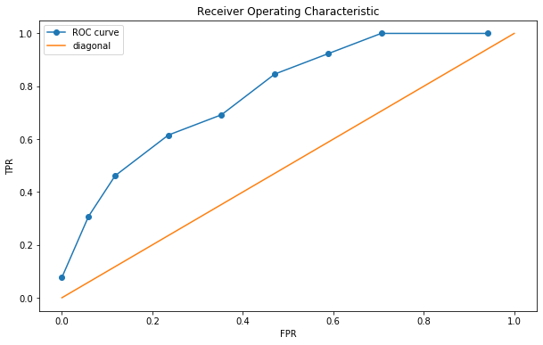

```python
plt.subplots(figsize=(10, 6))
plt.plot(fpr, tpr, 'o-', label="ROC curve")
plt.plot(np.linspace(0,1,10), np.linspace(0,1,10), label="diagonal")
plt.legend(loc="upper left")
plt.title('Receiver Operating Characteristic')
plt.xlabel("FPR")
plt.ylabel("TPR")
plt.show()
```